# ASSIGNMENT ONE

ETANA DISASA

5/14/2019

## USING R TO UNDERSTAND A DATASET

### INTRODUCTION

This assignment attepts to utilize a number of R commands to read, analyze and interpret data acquired from the datasets and to provide insight. The first dataset utilized was recovered from the U.S. Vetrans Affairs website https://www.va.gov/vetdata/docs/SpecialReports/Vietnam_Veterans_by_State.xlsx. The second one is R’s built-in Iris dataset.

### R Commands

#### 1. [read_excell] Command

This command is part of the readxl library. Therefore, the library must be called first for the command to return result. This command imports Mircosoft Excel (XLSX) files.

```r
library(readxl)
Veterans <- read_excel("Vietnam_Veterans_by_State.xlsx")
```

##### 2. [names( )] Command

Once the dataset is imported, the names() command reads the different attributes/variables in the dataset. In other words, in this case it lists the names of the columns of the table. The result is, we have 15 Variables in this dataset.

```r
names(Veterans)
```

```
##  [1] "States"               "Population"           "PercentFemale"
##  [4] "BelowPovertyLevel"    "DisabilityRate"       "MedianPersonalIncome"
##  [7] "White"                "Black"                "55-64"
## [10] "65-74"                "Above75"              "LessThanHighSchool"
## [13] "HighSchool"           "SomeCollege"          "BachelorDegree"
```

##### 3. [head( )] Command

This command reads the first few lines of a dataset. In this case, the dataset used is “Iris”.

```r
head(iris)
```

```
##   Sepal.Length Sepal.Width Petal.Length Petal.Width Species
## 1          5.1         3.5          1.4         0.2  setosa
## 2          4.9         3.0          1.4         0.2  setosa
## 3          4.7         3.2          1.3         0.2  setosa
## 4          4.6         3.1          1.5         0.2  setosa
## 5          5.0         3.6          1.4         0.2  setosa
## 6          5.4         3.9          1.7         0.4  setosa
```

##### 4. [tail( )] Command

Similar to the head() command, the tail command reads the last few lines of observation from the dataset.

```r
tail(iris)
```

```
##     Sepal.Length Sepal.Width Petal.Length Petal.Width   Species
## 145          6.7         3.3          5.7         2.5 virginica
## 146          6.7         3.0          5.2         2.3 virginica
## 147          6.3         2.5          5.0         1.9 virginica
## 148          6.5         3.0          5.2         2.0 virginica
## 149          6.2         3.4          5.4         2.3 virginica
## 150          5.9         3.0          5.1         1.8 virginica
```

##### 5. [summary( )] Command

This command provides the summaries for each variable in the dataset.

```r
summary(iris)
```

```
##   Sepal.Length    Sepal.Width     Petal.Length    Petal.Width
##  Min.   :4.300   Min.   :2.000   Min.   :1.000   Min.   :0.100
##  1st Qu.:5.100   1st Qu.:2.800   1st Qu.:1.600   1st Qu.:0.300
##  Median :5.800   Median :3.000   Median :4.350   Median :1.300
##  Mean   :5.843   Mean   :3.057   Mean   :3.758   Mean   :1.199
##  3rd Qu.:6.400   3rd Qu.:3.300   3rd Qu.:5.100   3rd Qu.:1.800
##  Max.   :7.900   Max.   :4.400   Max.   :6.900   Max.   :2.500
##        Species
##  setosa    :50
##  versicolor:50
##  virginica :50
##
##
##
```

##### 6. [sum( )] Command

This command returns the summation of all observations in one column of the dataset where all observations are numeric. In this case, the command is reading Sepal.Length column in the Iris dataset.

```r
sum(iris$Sepal.Length)
```

```
## [1] 876.5
```

##### 7. [mean( )] Command

The mean command returns the mean of the specified variable in the dataset.

```r
mean(iris$Sepal.Length)
```

```
## [1] 5.843333
```

##### 8. [median( )] Command

The median comman returns the median of the specified variable. In this case. Sepal.Width is the variable considered and the result is 3.

```r
median(iris$Sepal.Width)
```

```
## [1] 3
```

##### 9. [sd( )] Command

The sd command returns the standard deviation of a variable within the dataset; here, the standard deviation for the petal length (Petal.Length) is approximately 1.77.

```r
sd(iris$Petal.Length)
```

```
## [1] 1.765298
```

```r
mean(iris$Petal.Width)
```

```
## [1] 1.199333
```

##### 11. [cor( )] Command

The cor command returns the correlation between two numeric variables. In this case, Sepal.Length and Petal.Length has an approximately 87% correlation.

```r
cor(iris$Sepal.Length, iris$Petal.Length)
```

```
## [1] 0.8717538
```

##### 12. [hist( )] Command

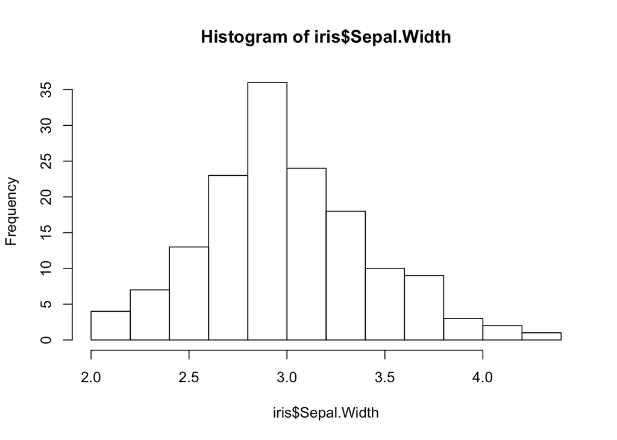

```r
hist(iris$Sepal.Width)
```

##### 13. [barplot( )] Command

The barplot command plots a bar plot. The plot below displays that the petal length of the observed flowers is much longer from Setosa to Versicolor to Virginica.

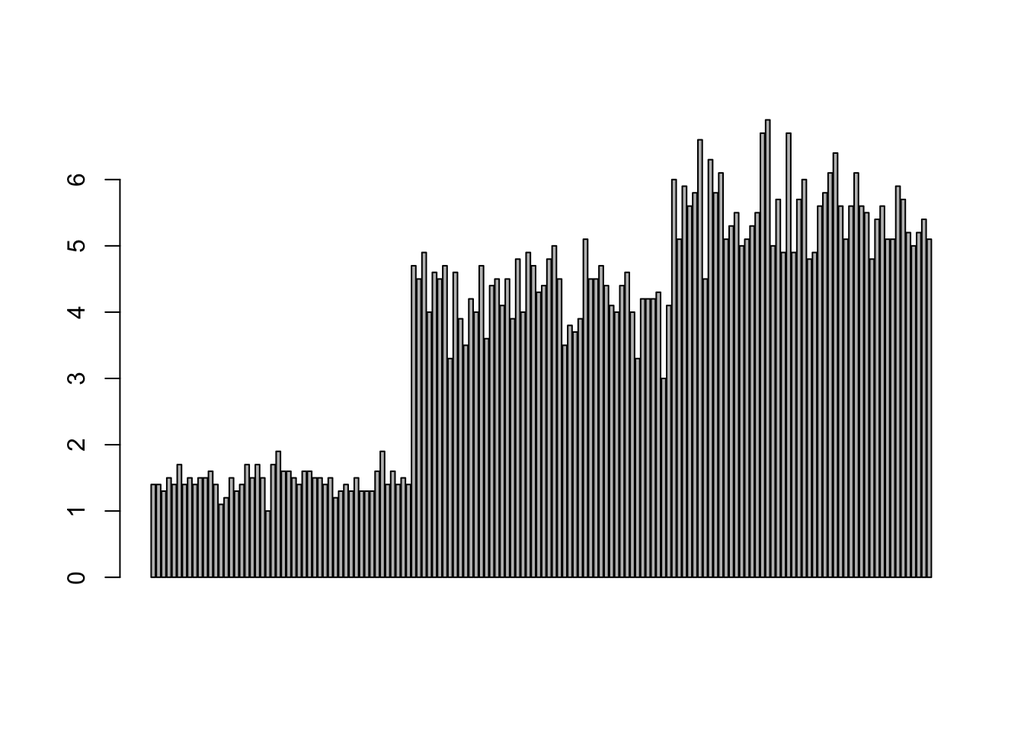

```r
barplot(iris$Petal.Length)
```

##### 14. [boxplot( )] Command

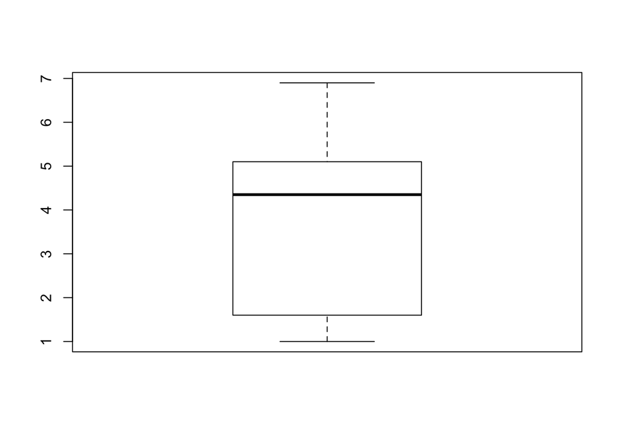

```r
boxplot(iris$Petal.Length)
```

##### 15. [plot( )] Command

The plot command creates a simple plot. Accordingly, the petal width of the observed flowers appears to be more and more wide from Setora to Versicolor to Virginica.

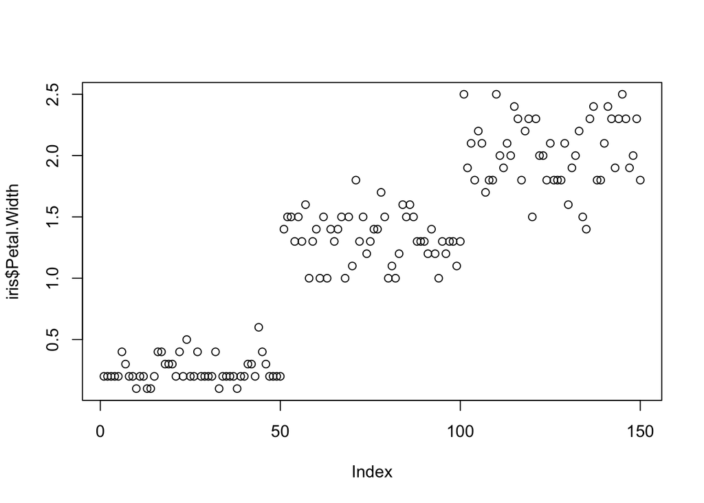

```r
plot(iris$Petal.Width)
```

### Conclusion

R offers several commands. The above discussed commands read data, perform descriptive statistics and generate graphical displays of findings.

### References

Department of Veterans Affairs. (2014). Vietnam_Veterans_by_State. https://www.va.gov/vetdata/docs/SpecialReports/Vietnam_Veterans_by_State.xlsx